# Machine Learning with `R`

# K-Nearest Neighbors (KNN)

# Introduction

Given a positive integer $K$ and a test observation $x$, the K-Nearest Neighbors (KNN) classifier first identifies the $K$ points in the training data that are closest to $x$. It then estimates the probability for every class $j$ of the response variable as the fraction of points in $K$ whose response values equal $j$. Then, it classifies the test observation $x$ to the class with the largest probability. Even if KNN is a very simple approach, it can often produce surprisingly good results. The key point in applying KNN is the choice of $K$, the number of closest observations to include in the neighbor of a given point. When $K$ is small, the method produces very flexible decision boundaries. As $K$ grows, the method becomes less flexible and produces decision boundaries that are close to linear. $K$ is usually chosen using an approach called “cross-validation”.

One advantage of KNN is that it is a completely non-parametric approach, because no assumptions are made about the shape of the decision boundaries. Therefore, KNN can produce better results than LDA and logistic regression especially when the decision boundaries are highly non-linear. On the other hand, KNN is less informative than LDA and logistic regression, because it doesn’t provide an intuition about which predictors are important for discriminating the response classes, since it doesn’t produce a table of coefficients.

## Example: Stock Market Data

We now apply KNN to `Smarket` (see the section *Introduction and datasets used* for further information), the same stock market data we already presented for LDA. The package `caret` contains the function `knn3Train()` which directly returns the predictions for the response variable. This function requires the predictor values for both the training and test data, the class labels for the training observations, and a value for $K$. We still use the data from 2005 as the test set and all the remaining observations for training:

```r
require(caret)
```

```r
train <- (Smarket$Year < 2005)
train_X <- Smarket[train, c("Lag1", "Lag2")]
test_X <- Smarket[!train, c("Lag1", "Lag2")]
train_Y <- Smarket[train, "Direction"]
test_Y <- Smarket[!train, "Direction"]
set.seed(123)   # the random seed is needed because R will break ties at random
knn_pred_1 <- knn3Train(train_X, test_X, train_Y, k = 1, use.all = FALSE)
confusionMatrix(data = knn_pred_1, reference = test_Y, positive = "Up")
```

```
## Confusion Matrix and Statistics
##
##           Reference
## Prediction Down Up
##       Down   43 58
##       Up     68 83
##
##                Accuracy : 0.5
##                  95% CI : (0.4366, 0.5634)
##     No Information Rate : 0.5595
##     P-Value [Acc > NIR] : 0.9751
##
##                   Kappa : -0.0242
##  Mcnemar's Test P-Value : 0.4227
##
##             Sensitivity : 0.5887
##             Specificity : 0.3874
##          Pos Pred Value : 0.5497
##          Neg Pred Value : 0.4257
##              Prevalence : 0.5595
##          Detection Rate : 0.3294
##    Detection Prevalence : 0.5992
##       Balanced Accuracy : 0.4880
##
##        'Positive' Class : Up
##
```

Using `k = 1` only 50% of the observations in the test set are correctly predicted. We now repeat the analysis using `k = 3`:

```r
knn_pred_3 <- knn3Train(train_X, test_X, train_Y, k = 3, use.all = FALSE)
confusionMatrix(data = knn_pred_3, reference = test_Y, positive = "Up")
```

```
## Confusion Matrix and Statistics
##
##           Reference
## Prediction Down Up
##       Down   48 55
##       Up     63 86
##
##                Accuracy : 0.5317
##                  95% CI : (0.4681, 0.5946)
##     No Information Rate : 0.5595
##     P-Value [Acc > NIR] : 0.8294
##
##                   Kappa : 0.0427
##  Mcnemar's Test P-Value : 0.5193
##
##             Sensitivity : 0.6099
##             Specificity : 0.4324
##          Pos Pred Value : 0.5772
##          Neg Pred Value : 0.4660
##              Prevalence : 0.5595
##          Detection Rate : 0.3413
##    Detection Prevalence : 0.5913
##       Balanced Accuracy : 0.5212
##
##        'Positive' Class : Up
##
```

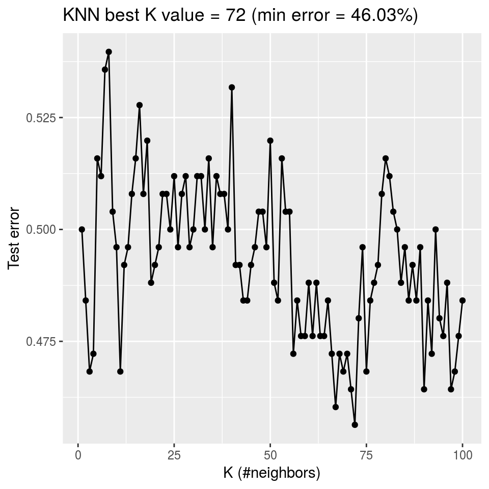

```r
kmax <- 100
test_error <- numeric(kmax)
for (k in 1:kmax) {
  knn_pred <- knn3Train(train_X, test_X, train_Y, k = k, prob = FALSE,
                          use.all = FALSE)
    cm <- confusionMatrix(data = knn_pred, reference = test_Y, positive = "Up")
    test_error[k] <- 1 - cm$overall[1]
}
k_min <- which.min(test_error)
knn_pred_min <- knn3Train(train_X, test_X, train_Y, k = k_min, prob = FALSE,
                         use.all = FALSE)
cm <- confusionMatrix(data = knn_pred_min, reference = test_Y, positive = "Up")
ggp <- ggplot(data.frame(test_error), aes(x = 1:kmax, y = test_error)) +
    geom_line() +
  geom_point() +
  xlab("K (#neighbors)") + ylab("Test error") +
    ggtitle(paste0("KNN best K value = ", k_min,
                   " (min error = ",
                   format((1 - cm$overall[1])*100, digits = 4), "%)"))
print(ggp)
```

`k = 72` seems to provide the smallest test error rate (around 46%). To conclude, it seems that KNN does not provide a better result than LDA and QDA.

The `caret` package provides many very general functions, such as `train()`, for fitting a wide range of predictive models using cross-validation or other resampling methods, but these functions are considerably more complicated to be used.